# Notebook

### Фактический запуск 14.09.2026

Все вычислительные ячейки выполнены. Техническое исполнение не подтверждает научные интерпретации исторического текста. Полный журнал — `legacy-execution.json`.

## Статус воспроизведения исторической редакции

Повторный технический запуск не подтверждает научные выводы старой редакции. Ниже сохранены прежние допущения и интерпретации; их следует сверять с текущими правилами проекта. Дыхательная и ЭКГ-разметка исторических расчётов не получает статус принятой при повторном запуске. Значения толщины 15 и 40 мм — исторические сценарии, а не заново проверенные измерения по КТ. Старые оценки сердечного происхождения сигнала и функций сердца не считаются валидированными.

```
Исторические входы скопированы; запись в исходные метки и параметры исключена.
```

# Указатель происхождения: 02_Kandidadskaya.ipynb

> **Статус:** санифицированный указатель, а не копия исходного расчёта.
- Исходный путь: `Colab Notebooks/02_Kandidadskaya.ipynb`.
- Исходный коммит: `1ac7813654b59861e359cffe3ad40941baeab2d9`.
- Контрольные суммы и ID ячеек: `../../MIGRATION_MANIFEST_2026-08-26.json`.
- Текущий действующий владелец до проверенного разделения: `../../70.01_Паспорт_и_QC_эксперимента_1_РЕО32.ipynb`.
- Локальный несанифицированный снимок при необходимости хранится в `../private/` и исключён из Git.

Исходные ячейки восстановлены ниже из указанного коммита. Эта редакция остаётся исторической.

Нормостеник

5 отв. - поперек сердца (180 х 90)

7 отв. - первый слой (140 х 70 )

9 отв. - вдоль сердца (180 х 90)

13 отв. - правое легкое (6 межреберье, 5 см от грудины и позвоночника, 5 см между потенциальным и токовым)

Сердце 180х90  
a=90, b=45

Мягкие 140х70

a=70, b=35

Построение всех графиков из txt файла из РЕО.

Название графика- folder/folder/***.txt

графики сортируются по возрастанию номера канала.

Галочками по умолчанию отключен вывод базового импеданса и по умолчанию включена инверсия ЭКГ.

После выбора каналов необходимо обновить график.

В справочных данных выводится среднее значение базового импеданса.

Другой способ вывода графика (через Altair)

Показался удобне, поскольку есть зум и прям в самом графике можно выбирать необходимые каналы, без надобности кликать по галочкам и обновлять.

!!!

Выбранные выше параметры для одного графика подтягиваются сюда для генерации всех графиков

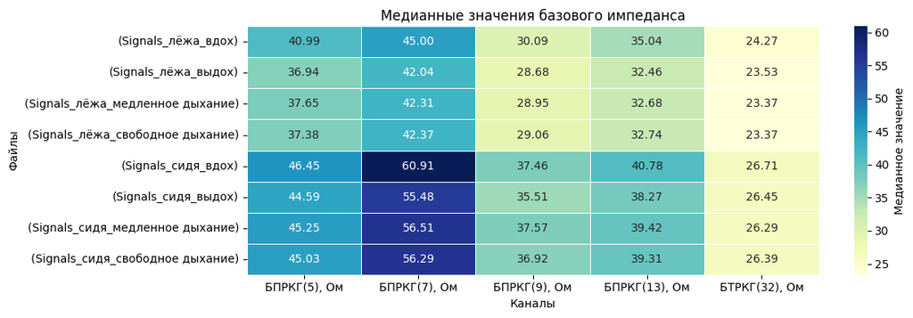

```
Доступные файлы:
0: (Signals_лёжа_вдох)
1: (Signals_лёжа_выдох)
2: (Signals_лёжа_медленное дыхание)
3: (Signals_лёжа_свободное дыхание)
4: (Signals_сидя_вдох)
5: (Signals_сидя_выдох)
6: (Signals_сидя_медленное дыхание)
7: (Signals_сидя_свободное дыхание)

Доступные каналы:
0: БПРКГ(5), Ом
1: БПРКГ(7), Ом
2: БПРКГ(9), Ом
3: БПРКГ(13), Ом
4: БТРКГ(32), Ом

Выбрано: файл = '(Signals_лёжа_вдох)', канал = 'БПРКГ(7), Ом'
Медианное значение (z) = 45.0
Технический сценарий, не принятый расчёт функции сердца: {'relative_file': 'лёжа/вдох.txt', 'baseline_channel': 'БПРКГ(7), Ом', 'pulse_channel': 'ПРКГ(5), мОм', 'pulse_window_s': [4, 5], 'status': 'technical_reproduction_scenario_not_accepted_physiological_estimate'}
Полуразмах выбранного канала, Ом: 0.046242
```

Расчёты ==ДЛЯ ОДНОЙ ЭЛЕКТРОДНОЙ СБОРКИ==

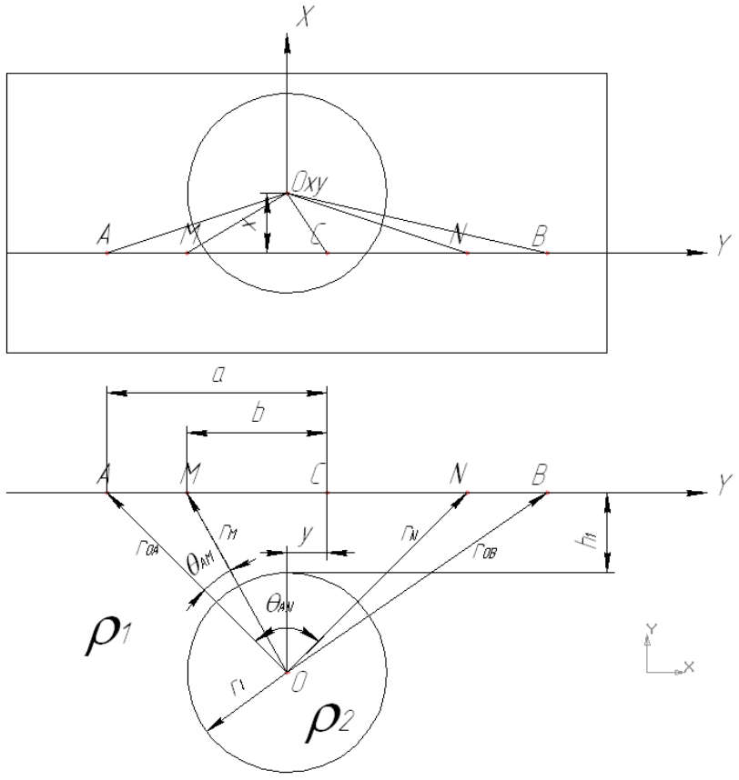

## Уравнения и переменные: происхождение и значения

Сводный справочник ко всей модели одной сборки. Полный вывод «с нуля» — в 01_Математическая_модель_импеданса.md; перекрёстная (двухсборочная) локализация и идентифицируемость — в 15_Кросс_локализация_и_траектории_сферы.md.

### Уравнения

| Формула | Смысл | Откуда (вывод) | В коде |
| --- | --- | --- | --- |
| $Z_{\text{одн}}=\dfrac{2\rho_1 b}{\pi(a^2-b^2)}$ | импеданс однородного полупространства без сферы | тетраполярная комбинация потенциалов точечного источника с зеркальным изображением от изолирующей поверхности (doc 01 §2.1–2.2, ф. 4) | `one_layer_model`; первое слагаемое `Zbase`, `optimized_Zbase_scalar` |
| $A_n=\dfrac{n(\rho_2-\rho_1)}{(n+1)\rho_2+n\rho_1}$ | мультипольный коэффициент сферы, порядок $n$ | граничные условия (непрерывность потенциала и нормального тока) на поверхности шара $r=R$ (doc 01 §3.2) | `coefs = n*(rho2-rho1)/((n+1)*rho2+n*rho1)` |
| $dZ_{pq}=\dfrac{\rho_1}{\pi r_0}\sum\limits_{n=1}^{N}\left(\dfrac{R}{r_{\text{in}}}\right)^{n+1}\!\left(\dfrac{R}{r_0}\right)^{n}\!A_n P_n(\cos\theta)$ | возмущение импеданса от сферы для одной пары источник–приёмник | разложение возмущённого потенциала по полиномам Лежандра + учёт изолирующей поверхности тела (doc 01 §3.3–3.4, ф. 7) | `dZ_component` / `compute_component` / `vectorized_component` |
| $dZ=dZ_{AM}-dZ_{AN}+dZ_{BN}-dZ_{BM}$ | вклад сферы для тетраполярной сборки | та же знаковая комбинация 4 пар, что и в $Z_{\text{одн}}$ (doc 01 §3.5, ф. 10) | `dZ_total`; `dz_am - dz_an + dz_bn - dz_bm` |
| $\boxed{Z=Z_{\text{одн}}+dZ}$ | полный импеданс сборки (прямая задача) | сумма (4)+(10) (doc 01 §3.5, ф. 11) | `Zbase`, `optimized_Zbase_scalar` |
| $\rho_1=\dfrac{Z\,\pi(a^2-b^2)}{2b}$ | оценка $\rho_1$ по базовому импедансу | обращение однослойной модели (4) относительно $\rho_1$ (doc 01 §2.3, ф. 5) | `return_rho1` |
| $F(R)=Z(R)-Z^{*}=0$ | обратная задача: радиус по импедансу | монотонность $Z(R)$ на физиологич. интервале ⇒ единственный корень (doc 01 §5.1, ф. 16) | `find_r1_surface` через `scipy.optimize.brentq` |
| $Z_1=Z_{\text{баз}}+\tfrac12 A_Z,\ Z_2=Z_{\text{баз}}-\tfrac12 A_Z$ | импеданс в систолу / диастолу | $\rho_2<\rho_1$: больший радиус (диастола) ⇒ меньший $Z$ (doc 01 §5.2) | ячейка «Из графика пульсового импеданса…» |
| $Z_{\text{2сл}}$ (ряд изображений с $k=\tfrac{\rho_2-\rho_1}{\rho_2+\rho_1}$) | плоская двуслойная модель (проверочная) | метод изображений для слоя над полупространством (doc 01 §3.7, ф. 13) | `two_layer_model` (в расчётах не используется) |

Углы $\theta_{pq}$ между направлениями на источник и приёмник — по теореме косинусов через евклидовы расстояния (doc 01 §3.3, ф. 9): `cos_theta_* = (RA**2 + RM**2 - |AM|**2)/(2*RA*RM)` и аналоги.

### Переменные и параметры

[output not shown]

### Замечания о точности и происхождении (важно)

1. **$\rho_1$ измеряется на мягких тканях, применяется к сердцу.** `rho1` вычисляется из канала мягких тканей с геометрией $140\times70$ (`fat_a,fat_b`), а в расчётах сердца используется геометрия $180\times90$ (`heart_a,heart_b`). Это намеренно (doc 01 §2.3): $\rho_1$ — свойство среды, а не сборки.
2. **$h$ — до верха сферы, не до центра.** В расстояния (ф. 2 doc 01) входит $R+h$, т.е. центр сферы лежит на глубине $R+h=65$ мм, а `h1`$=25$ мм — только зазор кожа→верх сферы. Частый источник путаницы.
3. **$\Delta r$ не задаётся вручную.** Систолический и диастолический радиусы вычисляются как корни $Z(R)-Z^*=0$ по измеренной полуамплитуде `half_amplitude_Z`; это устраняет прежнее несогласованное тестовое значение 10 мм.
4. **$x=y=0$ ⇒ латеральная чувствительность равна нулю.** В центрированной конфигурации $\partial Z/\partial x=\partial Z/\partial y=0$ (симметрийный ноль); это делает латеральное смещение ненаблюдаемым и разбирается в 15_Кросс_локализация_и_траектории_сферы.md.
5. **$\rho_2$ — внешний параметр.** Взят из отчёта РФФИ как типичное сопротивление крови/миокарда; не восстанавливается в этой модели, а задаётся.

Электрический импеданс, измеряемый между точками M и N (между потенциальными электродами) определяется соотношением (3)

$$ Z = Z_{\text{oДH}} + Z_{\text{cфер}} \tag{3} $$

$$Z = \frac{2 \rho_1 b}{\pi (a^2 - b^2)} + dZ(\rho_1, \rho_2, a, b, R, h, x, y) \tag{4} $$

В модели сокращение сердца описывается изменением радиуса эквивалентной сферы. Для обеспечения возможности независимого изменения радиуса эквивалентной сферы в области каждой электродной системы, для каждого из 2-х каналов рассматривается не только своя локальная эквивалентная сфера, но и свои геометрические параметры математической модели. $$ Z_i = \frac{2 \cdot \rho_{1i} \cdot b}{\pi \cdot (a_i^2 - b_i^2)} + dZ(\rho_{1}, \rho_2, a_i, b_i, R_i, h_i, x_i, y_i) \tag{5} $$

```
rho1: 7.422013e+00 Ом*м
Исходя из данных в отчёте РФФИ rho2 можем принять за: 1.350000e+00 Ом*м
Итого, параметры эксперимента:
A: 9.000000e-02
B: 4.500000e-02
rho1: 7.422013e+00 Ом*м
rho2: 1.350000e+00 Ом*м
```

Радиус эквивалентной сферы $R_2$, соответствующий импедансу в момент времени после окончания систолы $Z_2$, определяется из соотношения (7).

$$\Delta Z = |Z_2 - Z_1| \tag{6}$$

$R_2 = func(Z_2, \rho_1, \rho_2, h, a, b, x, y) \tag{7}$$ Изменение радиуса $\Delta R$, соответствующее степени сокращения сердца в ходе систолы, определяется как разность радиуса эквивалентной сферы до и после сокращения (8). $$\Delta R = |R_2 - R_1| \tag{8}$$ Таким образом $\Delta R$ определяется по соотношению (9), где $R$ равно значению радиуса эквивалентной сферы перед началом систолы $R_1$. $$\Delta R = func(Z_1, \Delta Z, \rho_1, \rho_2, h, R, a, b, x, y) \tag{9}$$

Вычислительные эксперименты показали, что зависимость $Z(R)$ является нелинейной, но она монотонна на интервале физиологически возможных значений радиуса эквивалентной сферы $R$. Следовательно, $\Delta R$ может быть определена перебором при многократном  
решении прямой задачи определения импеданса $Z(R)$ или методами безусловной оптимизации функции, например, симплексным методом Нелдера-Мида.

Для построения графиков DeltaZ(DeltaR,DeltaX,DeltaY) или наоборот, нам нужно определить, относительно какого момента времени будем считать дельты.

Начальный момент- предсистола, когда:

1. Импеданс минимален
2. Радиус максимален
3. Сдвиг по координатам неизвестен

Данные из РФФИ по дельтам параметров во время сокращения сердца (получены из годографов)

| delta (мм) | Z | X | Y |
| --- | --- | --- | --- |
| 1 доброволец | (-5;+5) | (-5;0) | (0;3) |
| 2 доброволец | (-5;0) | (-1,5;+1,5) | (-2;2) |
| 3 доброволец | (-5;0) | (-2;2) | (-4;0) |

**Обоснование N=20 (число членов ряда Лежандра).** Ранее использовалось N=100, что вызывало переполнение float64 при построении полиномов через `scipy.special.legendre(n)`/`Legendre.basis(n)` для n≈90–100 (см. `RuntimeWarning: overflow encountered in scalar power`), хотя эти члены и так исчезающе малы.

Численно проверена сходимость ряда (относительно эталона N=300) в характерной граничной точке и на 2000 случайных точках из области анализа чувствительности (`problem['bounds']`: r1∈[0.03; 0.05] м, h1∈[0.01; 0.035] м, x0,y0∈[-0.005; 0.005] м). Это численная проверка выборки, а не строгая гарантия максимума ошибки по всей непрерывной области:

| N | относительная ошибка (граничная точка) | максимальная ошибка (2000 случайных точек в границах) |
| --- | --- | --- |
| 10 | 7.0e-06 | 4.0e-06 |
| 15 | 1.8e-08 | 5.7e-09 |
| **20** | **5.1e-11** | **1.9e-11** |
| 25 | 3.3e-13 | 6.4e-14 |
| 30+ | 0 (машинная точность) | 0 (машинная точность) |

В проверенной выборке N=20 даёт относительную ошибку порядка 1e-11 — на много порядков точнее экспериментальных данных. Одновременно `scipy.special.eval_legendre(n, x)` используется вместо `legendre(n)`/`Legendre.basis(n)`: он вычисляет значение через устойчивую рекуррентную формулу без построения объекта полинома, поддерживает векторизацию по массиву n и x напрямую и не переполняется на высоких степенях.

В случае учитывания кролвенаполения мягких тканей $\rho_1(t)$ из уравнения (3) зависит от времени и равняется $$ \rho_1(t) = \rho_{1баз} + \Delta\rho_1(t) \tag{11} $$

На практике, зная зависимость Δ$\rho_1(t)$, можно восстановить электроимпедансный сигнал, формируемый только изменением радиуса эквивалентной сферы. ля этого необходимо сначала восстановить зависимость $R(t)$ из выражения 4, экспериментально определив Δ$\rho_1(t)$ и $Z(t)$, а затем, используя соотношение (3), рассчитать зависимость $dZ(t)$

```
dZ_total = -2.850456e+00 Ом
Zbase = 3.214954e+01 Ом
```

```
dZ = -2.850456e+00 Ом
Zbase_opt = 3.214954e+01 Ом
```

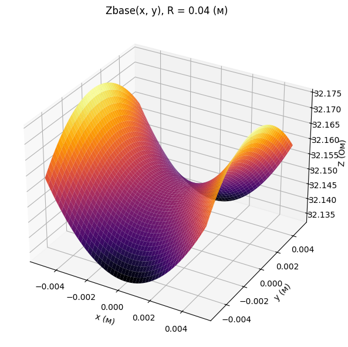

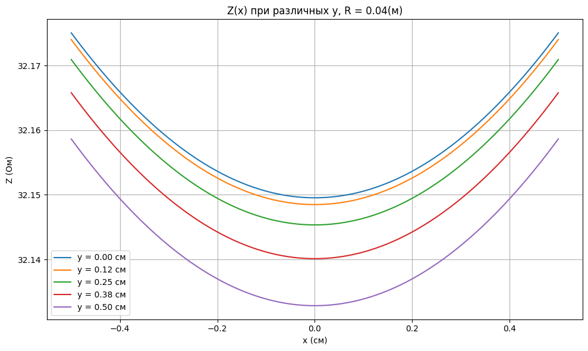

[figure not shown]

```
          mu   mu_star     sigma  mu_star_conf
r1 -2.875341  2.875341  1.279569      0.250138
h1  3.843014  3.843014  1.440587      0.292368
x0 -0.010816  0.044108  0.049976      0.004929
y0  0.004249  0.035041  0.044717      0.005771
```

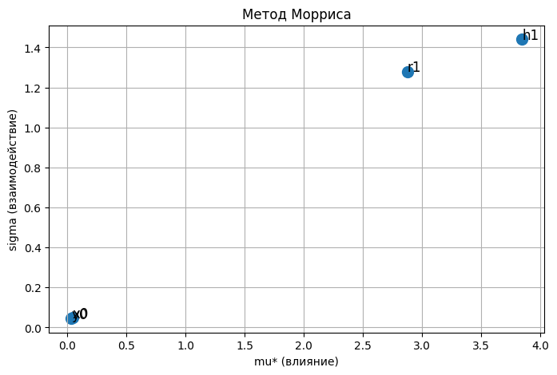

```
          ST   ST_conf
r1  0.360098  0.013003
h1  0.676521  0.020864
x0  0.000058  0.000003
y0  0.000039  0.000002
          S1   S1_conf
r1  0.323403  0.016268
h1  0.639817  0.021820
x0  0.000047  0.000237
y0  0.000023  0.000212
                S2   S2_conf
(r1, h1)  0.036696  0.034754
(r1, x0)  0.000010  0.022768
(r1, y0)  0.000020  0.022784
(h1, x0)  0.000009  0.030086
(h1, y0)  0.000015  0.030037
(x0, y0)  0.000002  0.000350
```

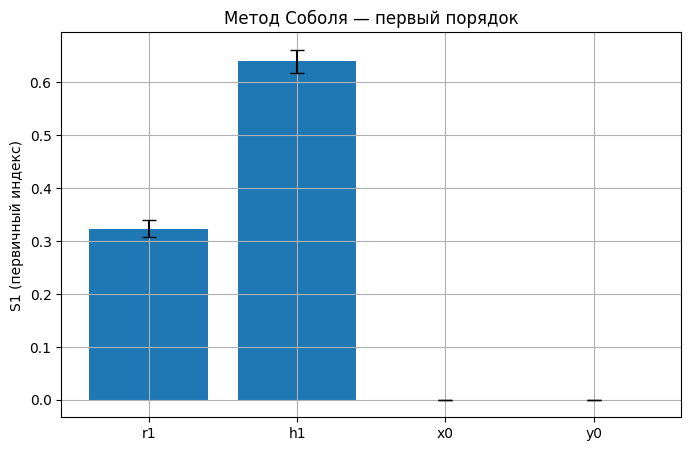

```
          S1        ST   S1_conf   ST_conf
r1  0.322715  0.359922  0.015241  0.040737
h1  0.637636  0.676445  0.015781  0.045351
x0  0.000059  0.000447  0.012660  0.042790
y0  0.000024  0.000375  0.013894  0.040131
```

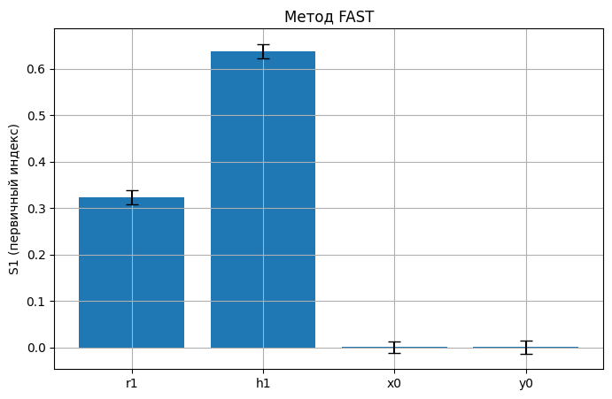

```
Коэффициенты полиномиальной регрессии для стандартизованных признаков:
r1: -1.6333
h1: -0.7355
x0: 0.0011
y0: 0.0016
r1 h1: 2.0460
r1 x0: -0.0013
r1 y0: 0.0033
h1 x0: -0.0001
h1 y0: -0.0045
x0 y0: 0.0007
```

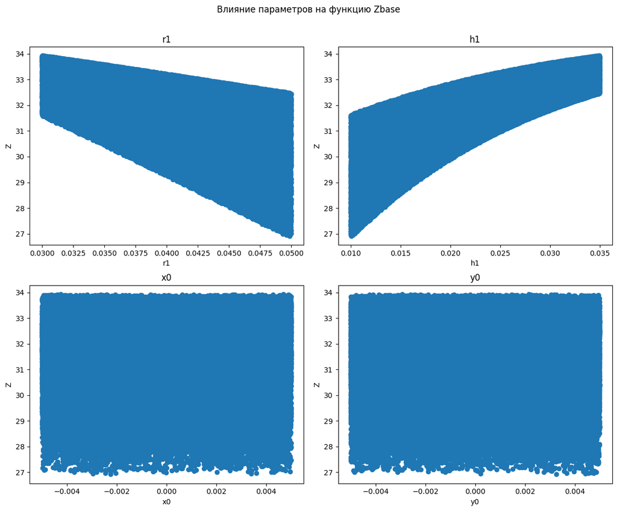

```
🔍 Влияние переменных и их взаимодействий на Zbase:
   feature  coefficient
5    r1 h1     2.036839
0       r1    -1.537413
8     h1^2    -1.149808
1       h1     0.415687
4     r1^2    -0.106154
11    x0^2     0.009383
13    y0^2    -0.007895
2       x0     0.007253
6    r1 x0    -0.007113
7    r1 y0     0.006431
10   h1 y0    -0.005392
3       y0    -0.001434
9    h1 x0    -0.000208
12   x0 y0    -0.000204
```

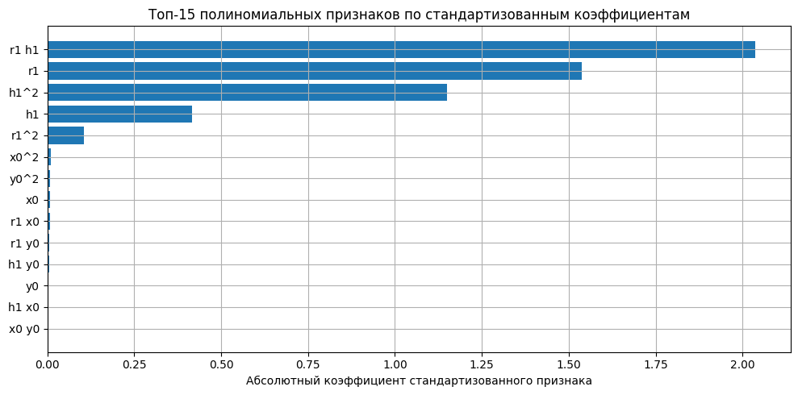

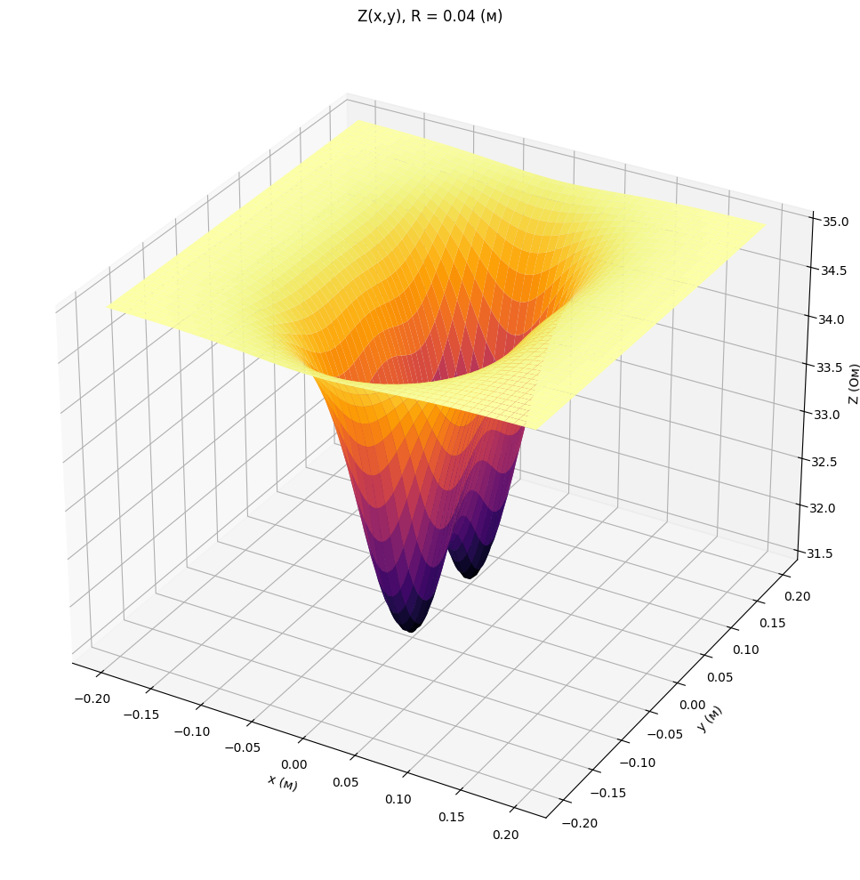

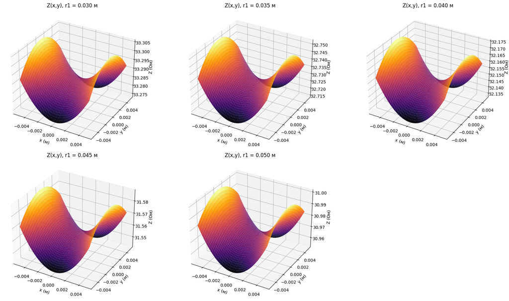

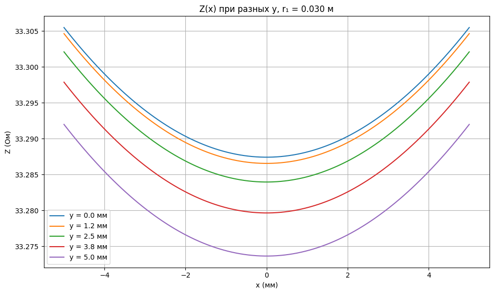

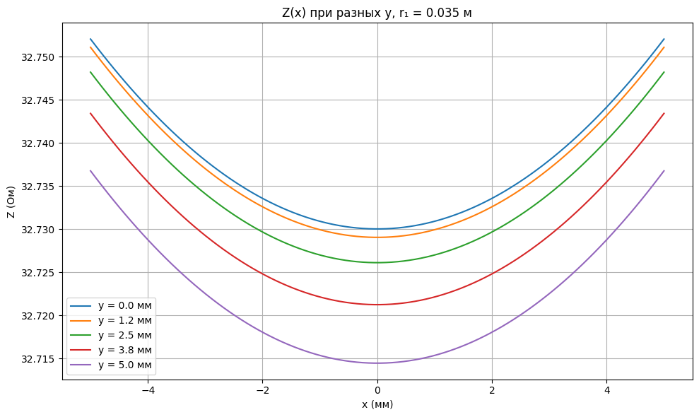

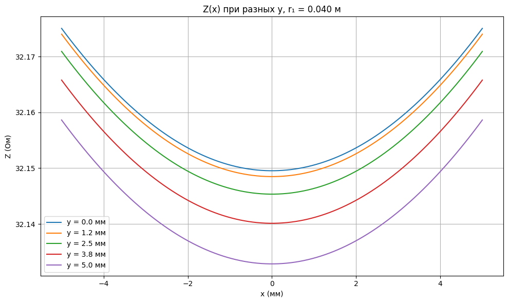

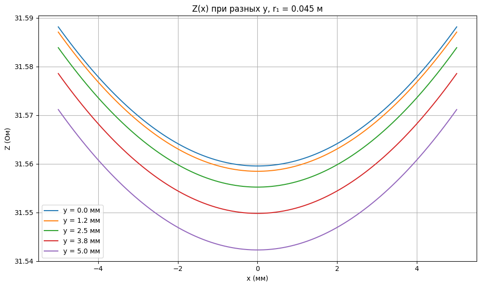

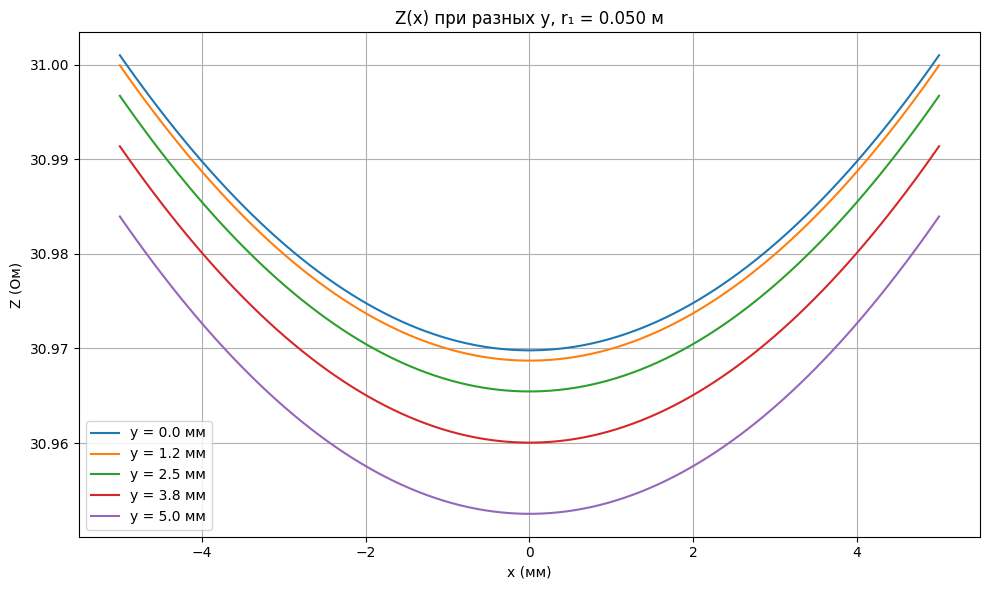

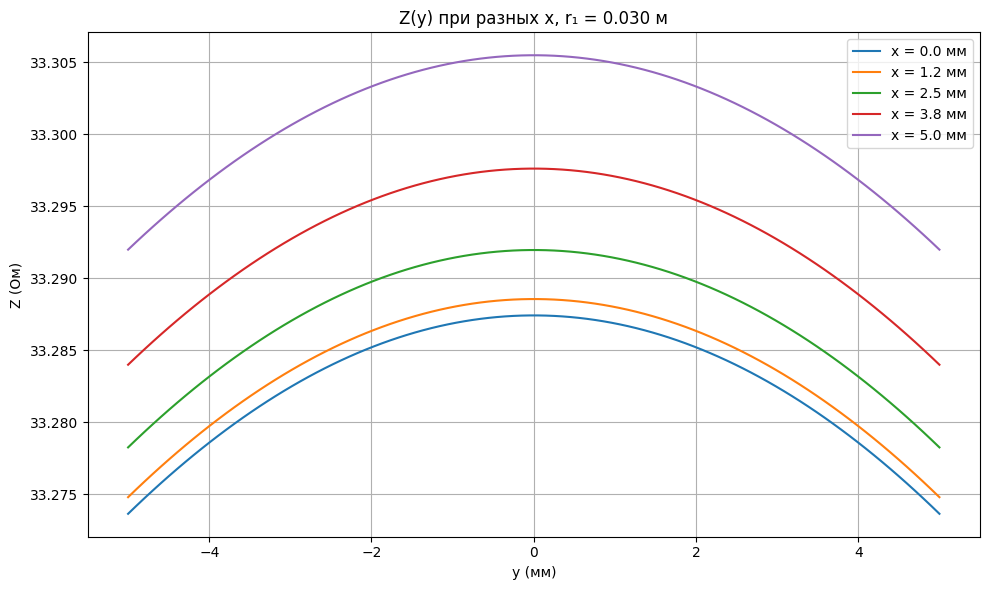

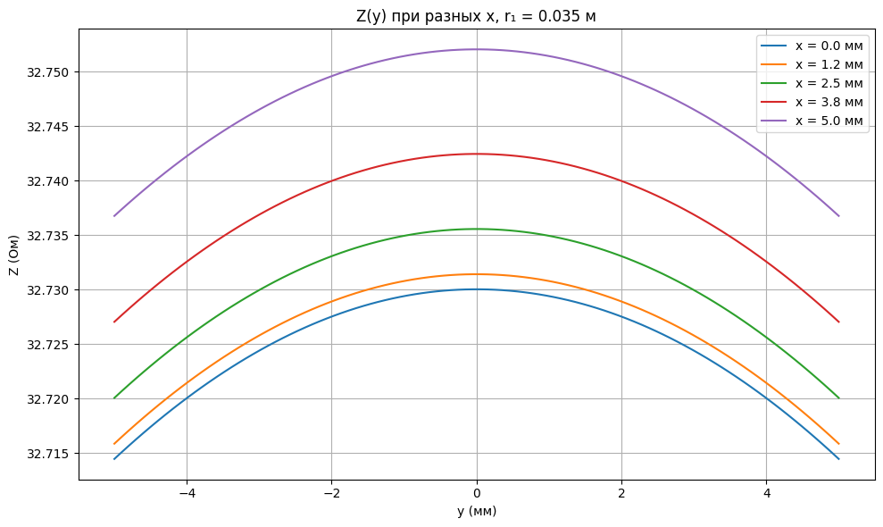

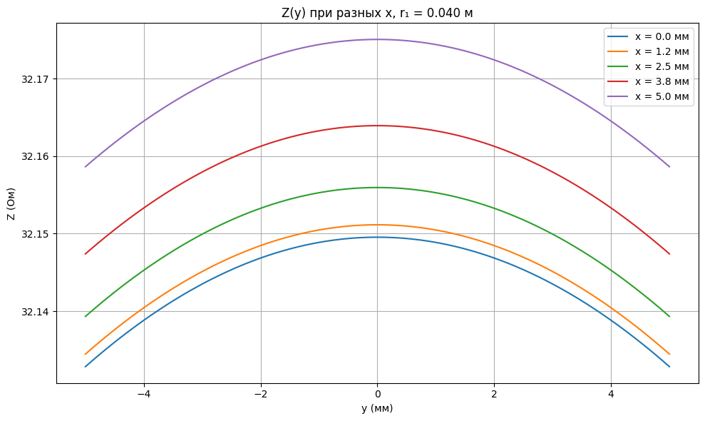

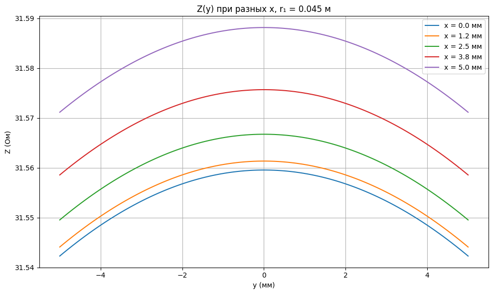

[12 more figures not shown]

```
⚠️ Обнаружены совпадающие по Z(r1) точки:
  → (0.000, 0.000), (0.005, 0.000), (0.000, 0.005), (0.0025, 0.0025), (0.005, 0.005)

📈 Линейная аппроксимация Z(r1) для каждой точки:

(0.000, 0.000): Z(r1) ≈ -116.1136·r1 + 36.7838  |  R² = 0.99987
(0.005, 0.000): Z(r1) ≈ -115.4569·r1 + 36.7826  |  R² = 0.99986
(0.000, 0.005): Z(r1) ≈ -116.2879·r1 + 36.7747  |  R² = 0.99988
(0.0025, 0.0025): Z(r1) ≈ -115.9934·r1 + 36.7813  |  R² = 0.99987
(0.005, 0.005): Z(r1) ≈ -115.6330·r1 + 36.7738  |  R² = 0.99987

📉 Средние изменения Z по r1 (в Ом/м):
Δr1 = -0.005 → среднее ΔZ/Δr1 = -117.71490 Ом/м
Δr1 = -0.005 → среднее ΔZ/Δr1 = -117.77666 Ом/м
Δr1 = -0.005 → среднее ΔZ/Δr1 = -115.88251 Ом/м
Δr1 = -0.005 → среднее ΔZ/Δr1 = -111.28130 Ом/м

🔁 Общее среднее изменение Z(r1): -115.66384 Ом/м
```

```
=== Анализ при h1 = 10.0 мм ===
```

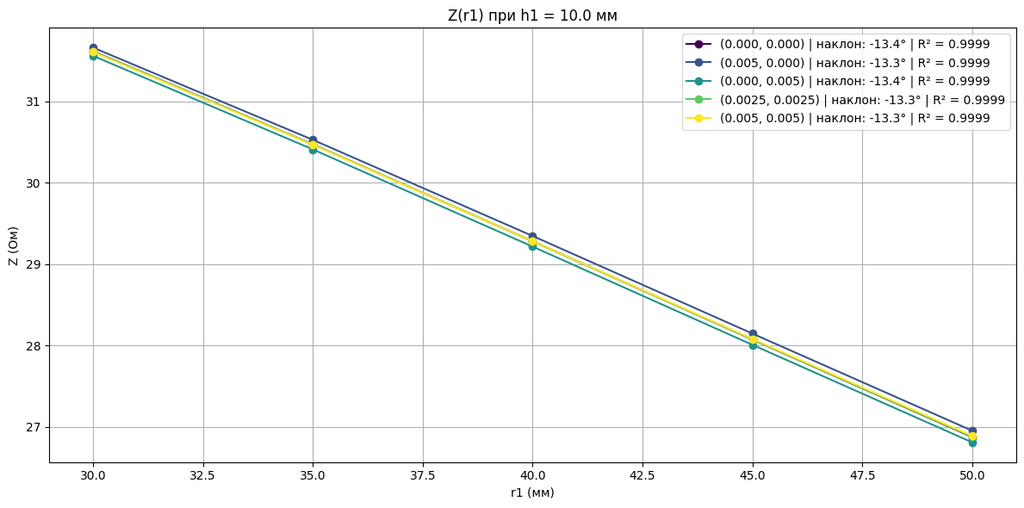

```
⚠️ Совпадающие точки:
  → (0.000, 0.000), (0.005, 0.000), (0.000, 0.005), (0.0025, 0.0025), (0.005, 0.005)

📈 Линейная аппроксимация Z(r1):
(0.000, 0.000): Z(r1) ≈ -237.4301·r1 + 38.7596  |  R² = 0.99990
(0.005, 0.000): Z(r1) ≈ -235.7946·r1 + 38.7575  |  R² = 0.99988
(0.000, 0.005): Z(r1) ≈ -237.9072·r1 + 38.7160  |  R² = 0.99992
(0.0025, 0.0025): Z(r1) ≈ -237.1464·r1 + 38.7485  |  R² = 0.99990
(0.005, 0.005): Z(r1) ≈ -236.2902·r1 + 38.7160  |  R² = 0.99991

📉 Средние изменения Z по r1 (в Ом/м):
Δr1 = -0.005 → среднее ΔZ/Δr1 = -239.13261 Ом/м
Δr1 = -0.005 → среднее ΔZ/Δr1 = -240.57844 Ом/м
Δr1 = -0.005 → среднее ΔZ/Δr1 = -237.54769 Ом/м
Δr1 = -0.005 → среднее ΔZ/Δr1 = -228.24684 Ом/м

🔁 Общее среднее изменение Z(r1): -236.37639 Ом/м


=== Анализ при h1 = 15.0 мм ===
```

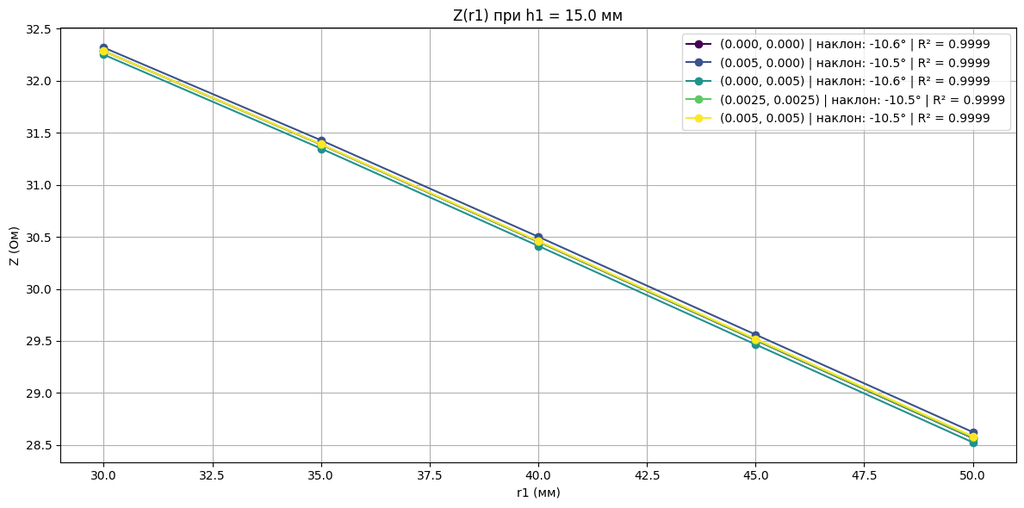

```
⚠️ Совпадающие точки:
  → (0.000, 0.000), (0.005, 0.000), (0.000, 0.005), (0.0025, 0.0025), (0.005, 0.005)

📈 Линейная аппроксимация Z(r1):
(0.000, 0.000): Z(r1) ≈ -186.3976·r1 + 37.8962  |  R² = 0.99990
(0.005, 0.000): Z(r1) ≈ -185.2055·r1 + 37.8951  |  R² = 0.99989
(0.000, 0.005): Z(r1) ≈ -186.7292·r1 + 37.8700  |  R² = 0.99992
(0.0025, 0.0025): Z(r1) ≈ -186.1850·r1 + 37.8895  |  R² = 0.99990
(0.005, 0.005): Z(r1) ≈ -185.5464·r1 + 37.8701  |  R² = 0.99990

📉 Средние изменения Z по r1 (в Ом/м):
Δr1 = -0.005 → среднее ΔZ/Δr1 = -187.94796 Ом/м
Δr1 = -0.005 → среднее ΔZ/Δr1 = -188.82263 Ом/м
Δr1 = -0.005 → среднее ΔZ/Δr1 = -186.38594 Ом/м
Δr1 = -0.005 → среднее ΔZ/Δr1 = -179.30295 Ом/м

🔁 Общее среднее изменение Z(r1): -185.61487 Ом/м


=== Анализ при h1 = 20.0 мм ===
```

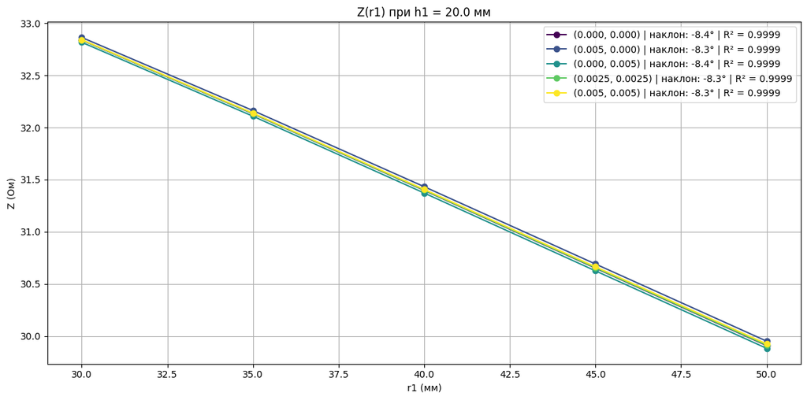

```
⚠️ Совпадающие точки:
  → (0.000, 0.000), (0.005, 0.000), (0.000, 0.005), (0.0025, 0.0025), (0.005, 0.005)

📈 Линейная аппроксимация Z(r1):
(0.000, 0.000): Z(r1) ≈ -146.8621·r1 + 37.2605  |  R² = 0.99989
(0.005, 0.000): Z(r1) ≈ -145.9815·r1 + 37.2595  |  R² = 0.99988
(0.000, 0.005): Z(r1) ≈ -147.1018·r1 + 37.2450  |  R² = 0.99990
(0.0025, 0.0025): Z(r1) ≈ -146.7029·r1 + 37.2565  |  R² = 0.99989
(0.005, 0.005): Z(r1) ≈ -146.2254·r1 + 37.2446  |  R² = 0.99989

📉 Средние изменения Z по r1 (в Ом/м):
Δr1 = -0.005 → среднее ΔZ/Δr1 = -148.42400 Ом/м
Δr1 = -0.005 → среднее ΔZ/Δr1 = -148.83580 Ом/м
Δr1 = -0.005 → среднее ΔZ/Δr1 = -146.72835 Ом/м
Δr1 = -0.005 → среднее ΔZ/Δr1 = -141.10344 Ом/м

🔁 Общее среднее изменение Z(r1): -146.27290 Ом/м


=== Анализ при h1 = 25.0 мм ===
```

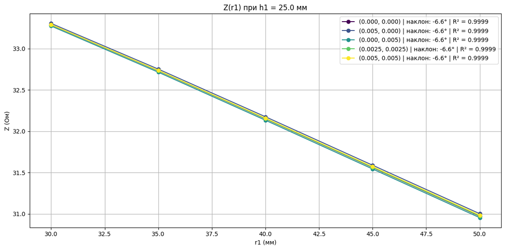

```
⚠️ Совпадающие точки:
  → (0.000, 0.000), (0.005, 0.000), (0.000, 0.005), (0.0025, 0.0025), (0.005, 0.005)

📈 Линейная аппроксимация Z(r1):
(0.000, 0.000): Z(r1) ≈ -116.1136·r1 + 36.7838  |  R² = 0.99987
(0.005, 0.000): Z(r1) ≈ -115.4569·r1 + 36.7826  |  R² = 0.99986
(0.000, 0.005): Z(r1) ≈ -116.2879·r1 + 36.7747  |  R² = 0.99988
(0.0025, 0.0025): Z(r1) ≈ -115.9934·r1 + 36.7813  |  R² = 0.99987
(0.005, 0.005): Z(r1) ≈ -115.6330·r1 + 36.7738  |  R² = 0.99987

📉 Средние изменения Z по r1 (в Ом/м):
Δr1 = -0.005 → среднее ΔZ/Δr1 = -117.71490 Ом/м
Δr1 = -0.005 → среднее ΔZ/Δr1 = -117.77666 Ом/м
Δr1 = -0.005 → среднее ΔZ/Δr1 = -115.88251 Ом/м
Δr1 = -0.005 → среднее ΔZ/Δr1 = -111.28130 Ом/м

🔁 Общее среднее изменение Z(r1): -115.66384 Ом/м


=== Анализ при h1 = 30.0 мм ===
```

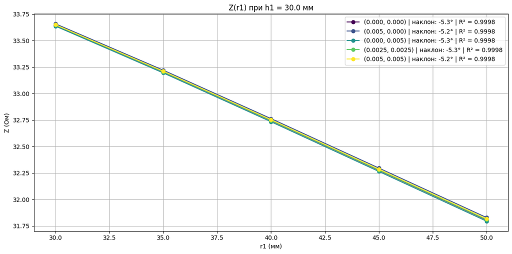

```
⚠️ Совпадающие точки:
  → (0.000, 0.000), (0.005, 0.000), (0.000, 0.005), (0.0025, 0.0025), (0.005, 0.005)

📈 Линейная аппроксимация Z(r1):
(0.000, 0.000): Z(r1) ≈ -92.1231·r1 + 36.4205  |  R² = 0.99984
(0.005, 0.000): Z(r1) ≈ -91.6300·r1 + 36.4192  |  R² = 0.99982
(0.000, 0.005): Z(r1) ≈ -92.2491·r1 + 36.4151  |  R² = 0.99985
(0.0025, 0.0025): Z(r1) ≈ -92.0315·r1 + 36.4189  |  R² = 0.99984
(0.005, 0.005): Z(r1) ≈ -91.7568·r1 + 36.4139  |  R² = 0.99984

📉 Средние изменения Z по r1 (в Ом/м):
Δr1 = -0.005 → среднее ΔZ/Δr1 = -93.74185 Ом/м
Δr1 = -0.005 → среднее ΔZ/Δr1 = -93.55297 Ом/м
Δr1 = -0.005 → среднее ΔZ/Δr1 = -91.82331 Ом/м
Δr1 = -0.005 → среднее ΔZ/Δr1 = -87.98428 Ом/м

🔁 Общее среднее изменение Z(r1): -91.77560 Ом/м


=== Анализ при h1 = 35.0 мм ===
```

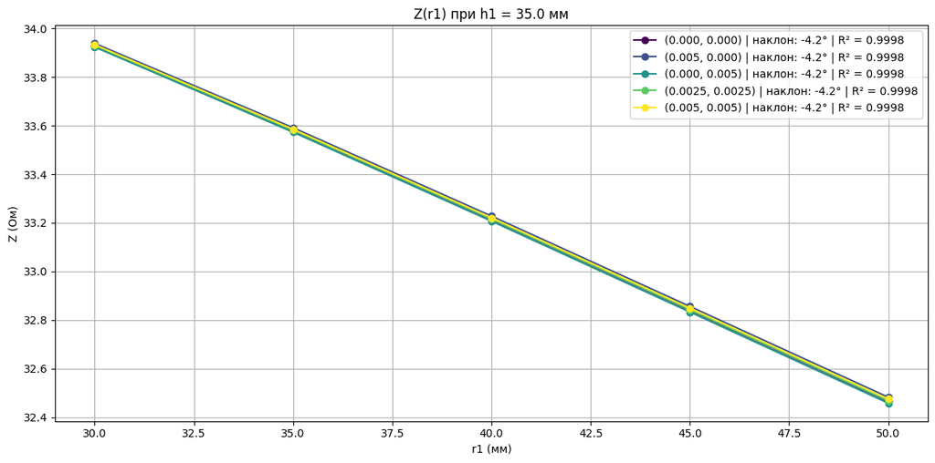

```
⚠️ Совпадающие точки:
  → (0.000, 0.000), (0.005, 0.000), (0.000, 0.005), (0.0025, 0.0025), (0.005, 0.005)

📈 Линейная аппроксимация Z(r1):
(0.000, 0.000): Z(r1) ≈ -73.3536·r1 + 36.1399  |  R² = 0.99979
(0.005, 0.000): Z(r1) ≈ -72.9815·r1 + 36.1386  |  R² = 0.99978
(0.000, 0.005): Z(r1) ≈ -73.4440·r1 + 36.1366  |  R² = 0.99981
(0.0025, 0.0025): Z(r1) ≈ -73.2832·r1 + 36.1388  |  R² = 0.99979
(0.005, 0.005): Z(r1) ≈ -73.0721·r1 + 36.1354  |  R² = 0.99979

📉 Средние изменения Z по r1 (в Ом/м):
Δr1 = -0.005 → среднее ΔZ/Δr1 = -74.95494 Ом/м
Δr1 = -0.005 → среднее ΔZ/Δr1 = -74.59654 Ом/м
Δr1 = -0.005 → среднее ΔZ/Δr1 = -73.01157 Ом/м
Δr1 = -0.005 → среднее ΔZ/Δr1 = -69.76735 Ом/м

🔁 Общее среднее изменение Z(r1): -73.08260 Ом/м
```

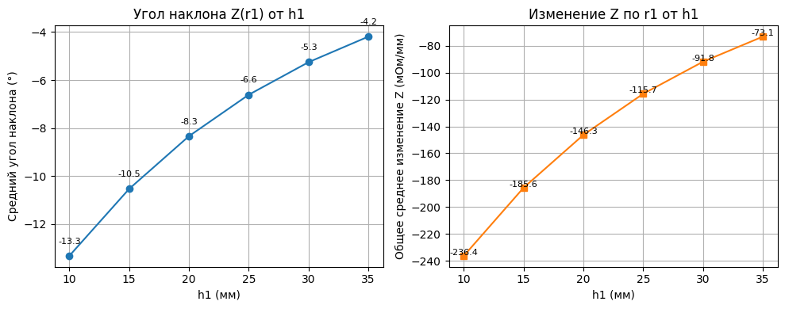

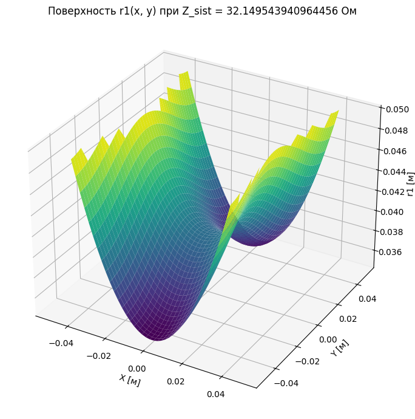

[figure not shown]